# Data 621 - Final Project

Anthony Munoz

5/22/2020

# Abstract

Breast cancer its one of the most common cancer nowadays in our society. For this project, I going to work with a dataset from Kaggle and also available on the UIC repository. In this project analysis we going to use regression modeling and try to replicate the outcome of the prediction which its this case we determine the change of cancer by declaring the results if they are Benign or Malignant. The modeling will try to come with the best accuracy prediction outcome. on this dataset we most will be working with the dimension and spect of the cancer cell.

# Introduction

In this paper analysis, we going to work on getting a results product prediction by finding some insight into the dataset. most of our predictor variables are cancer cell dimensions for which just will allow us just to predict those base on those features. This analysis won’t support other aspects that may be important in the analysis of cancer prediction such as, people age, use or drug or alcohol, and more.

*Key works: Cancer, cells,regression.

# Literature Review

When it comes to research on the type of cancer, breast cancer it’s one with a big notorious amount of research because it one of the most dangerous illnesses that affect thousands of women worldwide.

Breast cancer its one of the leading causes of death and compassion with other types of cancer. There have been many approaches to do analysis and predict the risk of breast cancer. many of these approaches are using logistic regression, Machine learning, SVM, and others modeling. LR, SVM and KNN approaches (Madhu Kumaria, Vijendra Singhb,2018).

Kumaria and Singh worked on different modeling techniques and were able to obtain an accuracy of 99.28. The methodology on how they worked with the dataset it’s similar on how I work with, for example, data selection, data processing/splitting the data, work with different model and select the most accurate one to test it on the evaluation dataset.

Breast cancer affects a range of different ages in a woman but according to this journal paper we see that more 89% percent of cancer was diagnosed with women older than 50 years old and just in 2017 more than 40,000 thousand women die because of this type of cancer(DeSantis, Jiemin Ma,Ann Goding Sauer, Newman,Ahmedin Jemal 2017).

# Methodology

The mythology for this project is to work with regression modeling on a dataset which contains 570 rows and 33 columns. this dataset source comes from Kaggle and UIC repository. the data will be split and 2 datasets first by having the training dataset and the evaluation dataset. Later apply the GLM regression model to the training sample data and select the most accurate ones to test it with the evaluation dataset.

# Experiment and results

## Data Exploratory

```
## Classes 'tbl_df', 'tbl' and 'data.frame':    367 obs. of  31 variables:
##  $ diagnosis              : num  1 1 1 1 1 1 1 1 1 1 ...
##  $ radius_mean            : num  11.4 20.3 18.2 13.7 12.5 ...
##  $ texture_mean           : num  20.4 14.3 20 20.8 24 ...
##  $ perimeter_mean         : num  77.6 135.1 119.6 90.2 84 ...
##  $ area_mean              : num  386 1297 1040 578 476 ...
##  $ smoothness_mean        : num  0.1425 0.1003 0.0946 0.1189 0.1186 ...
##  $ compactness_mean       : num  0.284 0.133 0.109 0.165 0.24 ...
##  $ concavity_mean         : num  0.2414 0.198 0.1127 0.0937 0.2273 ...
##  $ concave points_mean    : num  0.1052 0.1043 0.074 0.0599 0.0854 ...
##  $ symmetry_mean          : num  0.26 0.181 0.179 0.22 0.203 ...
##  $ fractal_dimension_mean : num  0.0974 0.0588 0.0574 0.0745 0.0824 ...
##  $ radius_se              : num  0.496 0.757 0.447 0.584 0.298 ...
##  $ texture_se             : num  1.156 0.781 0.773 1.377 1.599 ...
##  $ perimeter_se           : num  3.44 5.44 3.18 3.86 2.04 ...
```

[output cut: 23 more lines]

```
##    diagnosis       radius_mean      texture_mean   perimeter_mean
##  Min.   :0.0000   Min.   : 6.981   Min.   :10.82   Min.   : 43.79
##  1st Qu.:0.0000   1st Qu.:11.745   1st Qu.:16.05   1st Qu.: 76.09
##  Median :0.0000   Median :13.400   Median :18.75   Median : 86.60
##  Mean   :0.3706   Mean   :14.119   Mean   :19.37   Mean   : 91.94
##  3rd Qu.:1.0000   3rd Qu.:15.940   3rd Qu.:21.89   3rd Qu.:105.40
##  Max.   :1.0000   Max.   :27.420   Max.   :39.28   Max.   :186.90
##    area_mean      smoothness_mean   compactness_mean  concavity_mean
##  Min.   : 143.5   Min.   :0.05263   Min.   :0.01938   Min.   :0.00000
##  1st Qu.: 424.8   1st Qu.:0.08603   1st Qu.:0.06588   1st Qu.:0.02998
##  Median : 555.1   Median :0.09495   Median :0.09453   Median :0.06154
##  Mean   : 652.8   Mean   :0.09609   Mean   :0.10501   Mean   :0.08967
##  3rd Qu.: 785.6   3rd Qu.:0.10520   3rd Qu.:0.13050   3rd Qu.:0.12695
##  Max.   :2501.0   Max.   :0.14470   Max.   :0.34540   Max.   :0.42680
##  concave points_mean symmetry_mean    fractal_dimension_mean   radius_se
##  Min.   :0.00000     Min.   :0.1167   Min.   :0.04996        Min.   :0.1115
##  1st Qu.:0.02069     1st Qu.:0.1616   1st Qu.:0.05758        1st Qu.:0.2263
##  Median :0.03341     Median :0.1807   Median :0.06161        Median :0.3251
##  Mean   :0.04840     Mean   :0.1818   Mean   :0.06301        Mean   :0.4061
##  3rd Qu.:0.07013     3rd Qu.:0.1967   3rd Qu.:0.06670        3rd Qu.:0.4975
##  Max.   :0.20120     Max.   :0.3040   Max.   :0.09744        Max.   :2.5470
##    texture_se      perimeter_se       area_se        smoothness_se
##  Min.   :0.3628   Min.   : 0.757   Min.   :  6.802   Min.   :0.001713
##  1st Qu.:0.8332   1st Qu.: 1.565   1st Qu.: 17.595   1st Qu.:0.005084
##  Median :1.1400   Median : 2.308   Median : 25.180   Median :0.006307
##  Mean   :1.2311   Mean   : 2.877   Mean   : 40.233   Mean   :0.007052
##  3rd Qu.:1.4830   3rd Qu.: 3.307   3rd Qu.: 45.075   3rd Qu.:0.008214
##  Max.   :4.8850   Max.   :18.650   Max.   :542.200   Max.   :0.031130
##  compactness_se      concavity_se     concave points_se   symmetry_se
##  Min.   :0.002252   Min.   :0.00000   Min.   :0.000000   Min.   :0.007882
##  1st Qu.:0.013380   1st Qu.:0.01592   1st Qu.:0.007909   1st Qu.:0.015015
##  Median :0.021150   Median :0.02626   Median :0.010930   Median :0.018680
##  Mean   :0.026290   Mean   :0.03365   Mean   :0.011943   Mean   :0.020554
##  3rd Qu.:0.032460   3rd Qu.:0.04308   3rd Qu.:0.015125   3rd Qu.:0.023165
##  Max.   :0.135400   Max.   :0.39600   Max.   :0.052790   Max.   :0.078950
##  fractal_dimension_se  radius_worst   texture_worst   perimeter_worst
##  Min.   :0.0008948    Min.   : 7.93   Min.   :12.49   Min.   : 50.41
##  1st Qu.:0.0022490    1st Qu.:13.08   1st Qu.:21.05   1st Qu.: 84.81
##  Median :0.0032200    Median :14.92   Median :25.59   Median : 97.65
##  Mean   :0.0039368    Mean   :16.27   Mean   :25.81   Mean   :107.24
##  3rd Qu.:0.0046135    3rd Qu.:18.66   3rd Qu.:29.59   3rd Qu.:125.20
##  Max.   :0.0298400    Max.   :36.04   Max.   :49.54   Max.   :251.20
##    area_worst     smoothness_worst  compactness_worst concavity_worst
##  Min.   : 185.2   Min.   :0.07117   Min.   :0.02729   Min.   :0.0000
##  1st Qu.: 521.6   1st Qu.:0.11690   1st Qu.:0.15070   1st Qu.:0.1267
##  Median : 686.5   Median :0.13160   Median :0.21860   Median :0.2318
##  Mean   : 879.3   Mean   :0.13226   Mean   :0.25663   Mean   :0.2778
##  3rd Qu.:1060.0   3rd Qu.:0.14600   3rd Qu.:0.33680   3rd Qu.:0.3790
##  Max.   :4254.0   Max.   :0.20980   Max.   :1.05800   Max.   :1.2520
##  concave points_worst symmetry_worst   fractal_dimension_worst
##  Min.   :0.00000      Min.   :0.1565   Min.   :0.05504
##  1st Qu.:0.06567      1st Qu.:0.2525   1st Qu.:0.07209
##  Median :0.10450      Median :0.2818   Median :0.08025
##  Mean   :0.11436      Mean   :0.2903   Mean   :0.08454
##  3rd Qu.:0.16030      3rd Qu.:0.3156   3rd Qu.:0.09256
##  Max.   :0.29100      Max.   :0.6638   Max.   :0.20750
```

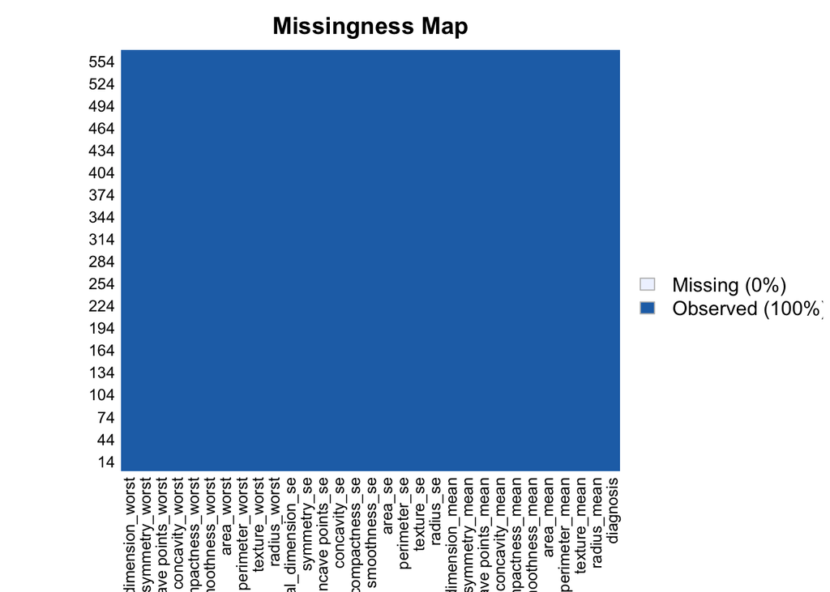

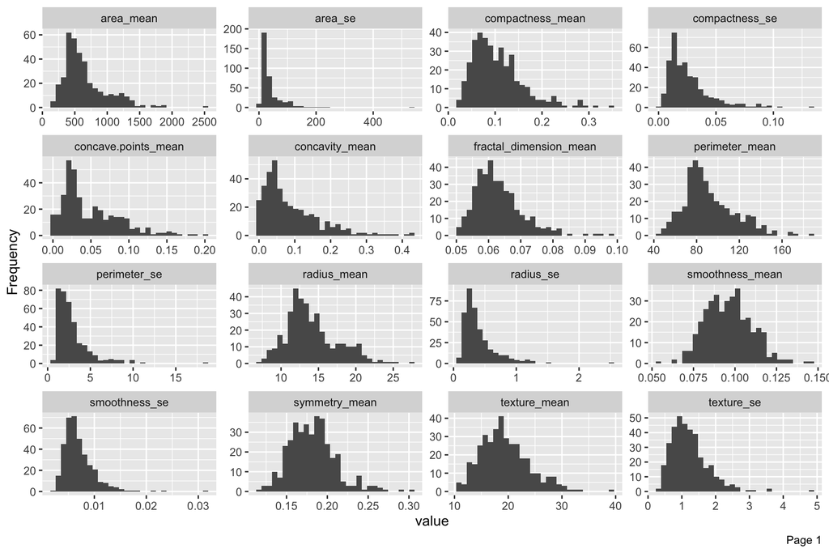

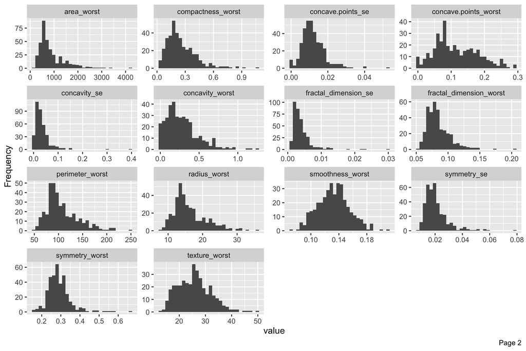

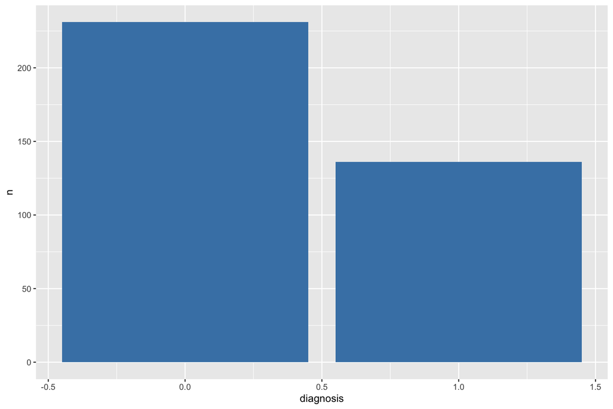

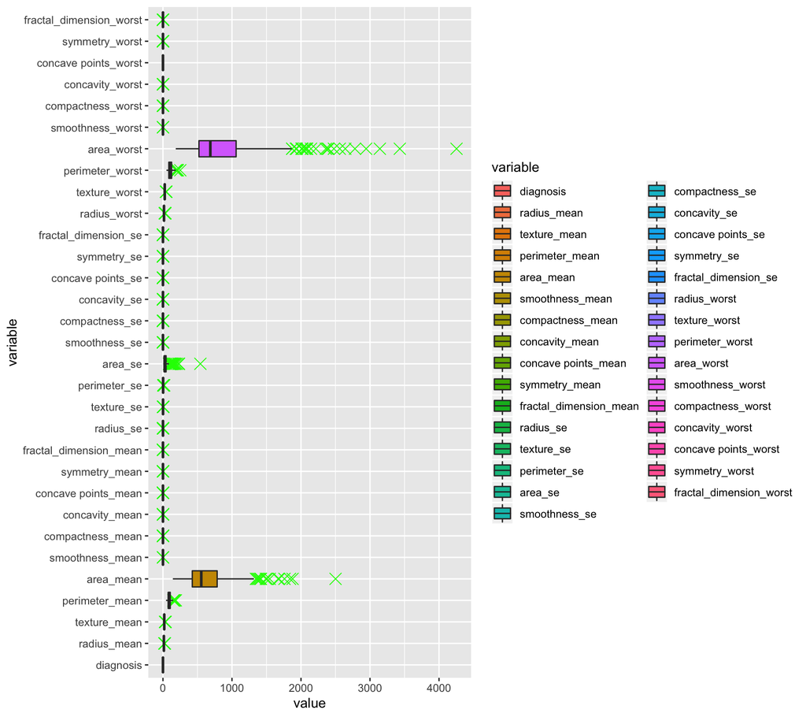

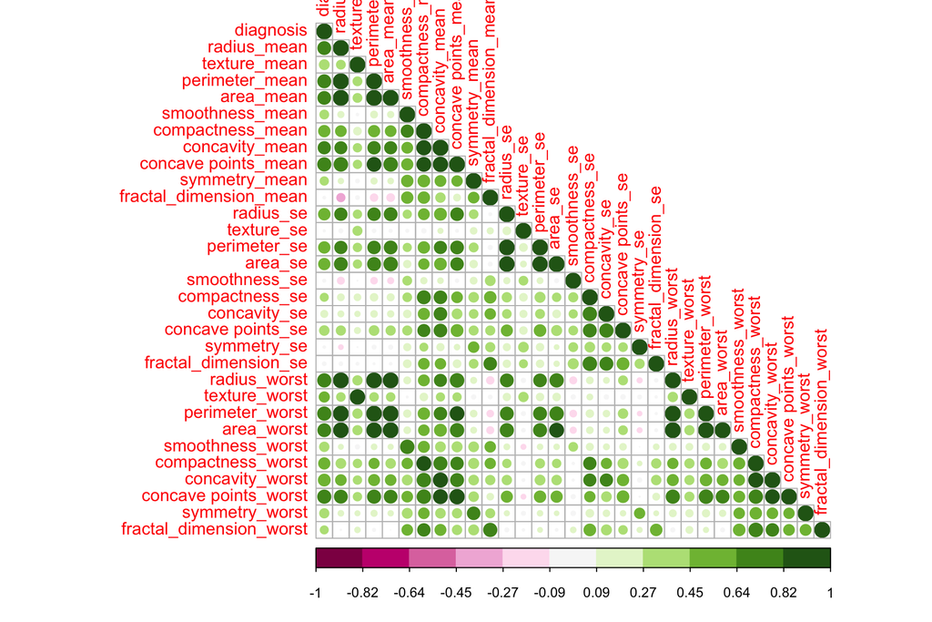

In the correlation plot we can observe they are many correlate variables for which this can be an issue and affect our modeling design. we going to use GLM modeling regression. we going to try to run a model with all the variables and then we going to implement a stepwise function in order to remove the correlate variables and enhance the model by obtaining one with just the most significant variables.

## Modeling

```
##
## Call:
## lm(formula = diagnosis ~ ., data = df.train)
##
## Residuals:
##      Min       1Q   Median       3Q      Max
## -0.52831 -0.15981 -0.02768  0.12972  0.76625
##
## Coefficients:
##                           Estimate Std. Error t value Pr(>|t|)
## (Intercept)             -1.391e+00  5.550e-01  -2.507 0.012664 *
## radius_mean             -3.804e-01  2.230e-01  -1.706 0.088971 .
## texture_mean             1.010e-02  9.920e-03   1.019 0.309148
## perimeter_mean           3.624e-02  3.240e-02   1.118 0.264153
## area_mean                9.176e-04  7.110e-04   1.291 0.197736
## smoothness_mean          1.513e+00  2.555e+00   0.592 0.553937
## compactness_mean        -3.847e+00  1.696e+00  -2.268 0.023959 *
## concavity_mean           1.602e+00  1.301e+00   1.232 0.218959
## `concave points_mean`    2.297e+00  2.676e+00   0.858 0.391340
## symmetry_mean            3.710e-01  9.487e-01   0.391 0.695982
## fractal_dimension_mean  -1.165e+01  6.955e+00  -1.675 0.094930 .
## radius_se                3.348e-01  4.066e-01   0.823 0.410866
## texture_se               9.555e-03  4.468e-02   0.214 0.830788
## perimeter_se            -1.453e-02  5.495e-02  -0.264 0.791591
## area_se                 -1.813e-03  1.794e-03  -1.011 0.312800
## smoothness_se            1.446e+01  7.983e+00   1.812 0.070920 .
## compactness_se           4.158e+00  2.742e+00   1.516 0.130352
## concavity_se            -4.595e+00  1.562e+00  -2.942 0.003482 **
## `concave points_se`      1.344e+01  7.287e+00   1.845 0.065952 .
## symmetry_se              1.635e+00  3.422e+00   0.478 0.633202
## fractal_dimension_se    -1.518e+01  1.437e+01  -1.056 0.291634
## radius_worst             2.652e-01  7.792e-02   3.404 0.000746 ***
## texture_worst            1.628e-03  8.687e-03   0.187 0.851479
## perimeter_worst         -7.680e-03  8.236e-03  -0.932 0.351760
## area_worst              -1.116e-03  4.044e-04  -2.759 0.006120 **
## smoothness_worst         5.192e-01  1.784e+00   0.291 0.771190
## compactness_worst       -8.214e-01  5.287e-01  -1.554 0.121227
## concavity_worst          6.217e-01  3.282e-01   1.894 0.059054 .
## `concave points_worst`  -1.798e-01  1.191e+00  -0.151 0.880064
## symmetry_worst           6.459e-01  6.506e-01   0.993 0.321567
## fractal_dimension_worst  8.316e+00  3.162e+00   2.630 0.008935 **
## ---
## Signif. codes:  0 '***' 0.001 '**' 0.01 '*' 0.05 '.' 0.1 ' ' 1
##
## Residual standard error: 0.2403 on 336 degrees of freedom
## Multiple R-squared:  0.7733, Adjusted R-squared:  0.753
## F-statistic:  38.2 on 30 and 336 DF,  p-value: < 2.2e-16
```

```
##
## Call:
## glm(formula = diagnosis ~ ., family = "binomial", data = df.train)
##
## Deviance Residuals:
##        Min          1Q      Median          3Q         Max
## -1.105e-04  -2.100e-08  -2.100e-08   2.100e-08   9.223e-05
##
## Coefficients:
##                           Estimate Std. Error z value Pr(>|z|)
## (Intercept)             -1.821e+03  3.238e+06  -0.001    1.000
## radius_mean             -8.469e+01  8.673e+05   0.000    1.000
## texture_mean            -5.114e+00  4.343e+04   0.000    1.000
## perimeter_mean           1.506e+01  1.856e+05   0.000    1.000
## area_mean               -3.980e-01  4.311e+03   0.000    1.000
## smoothness_mean          2.324e+03  1.145e+07   0.000    1.000
## compactness_mean        -2.708e+03  4.293e+06  -0.001    0.999
## concavity_mean           2.050e+03  2.779e+06   0.001    0.999
## `concave points_mean`   -4.276e+02  5.683e+06   0.000    1.000
## symmetry_mean            7.751e+02  1.644e+06   0.000    1.000
## fractal_dimension_mean  -1.981e+03  1.408e+07   0.000    1.000
## radius_se               -3.336e+02  4.610e+06   0.000    1.000
## texture_se              -7.474e+01  9.819e+04  -0.001    0.999
## perimeter_se             3.282e-01  1.662e+05   0.000    1.000
## area_se                  5.224e+00  3.762e+04   0.000    1.000
## smoothness_se            5.605e+03  3.796e+07   0.000    1.000
## compactness_se           5.485e+03  8.482e+06   0.001    0.999
## concavity_se            -3.832e+03  1.234e+07   0.000    1.000
## `concave points_se`      1.429e+04  1.077e+07   0.001    0.999
## symmetry_se             -1.157e+03  1.070e+07   0.000    1.000
## fractal_dimension_se    -5.302e+04  6.537e+07  -0.001    0.999
## radius_worst             1.170e+02  1.383e+05   0.001    0.999
## texture_worst            1.083e+01  2.818e+04   0.000    1.000
## perimeter_worst         -1.268e+00  2.478e+04   0.000    1.000
## area_worst              -7.123e-01  2.693e+03   0.000    1.000
## smoothness_worst         2.629e+02  9.213e+06   0.000    1.000
## compactness_worst       -5.801e+02  1.153e+06  -0.001    1.000
## concavity_worst          3.401e+02  1.928e+06   0.000    1.000
## `concave points_worst`  -1.180e+03  1.172e+06  -0.001    0.999
## symmetry_worst           5.488e+01  1.329e+06   0.000    1.000
## fractal_dimension_worst  6.855e+03  9.018e+06   0.001    0.999
##
## (Dispersion parameter for binomial family taken to be 1)
##
##     Null deviance: 4.8390e+02  on 366  degrees of freedom
## Residual deviance: 9.7274e-08  on 336  degrees of freedom
## AIC: 62
##
## Number of Fisher Scoring iterations: 25
```

```
##             radius_mean            texture_mean          perimeter_mean
##             256097.8071               3467.4213             522217.3047
##               area_mean         smoothness_mean        compactness_mean
##              49600.3179               1668.2554               3814.5445
##          concavity_mean   `concave points_mean`           symmetry_mean
##               1311.6570               1137.4900                238.5831
##  fractal_dimension_mean               radius_se              texture_se
##                672.0828              68980.3873                410.7646
##            perimeter_se                 area_se           smoothness_se
##               5093.1265              39410.7138               1122.0197
##          compactness_se            concavity_se     `concave points_se`
##               4542.0258               7650.4920                365.1819
##             symmetry_se    fractal_dimension_se            radius_worst
##               1078.8463               2125.5350               7528.5502
##           texture_worst         perimeter_worst              area_worst
##               4572.5422              11543.2887              28727.5436
##        smoothness_worst       compactness_worst         concavity_worst
##               4264.3094               3629.5564               7179.4142
##  `concave points_worst`          symmetry_worst fractal_dimension_worst
##                180.5555               1004.7855               2702.3783
```

```
##
## Call:
## glm(formula = diagnosis ~ ., family = binomial(link = "logit"),
##     data = df.train, trace = F)
##
## Deviance Residuals:
##        Min          1Q      Median          3Q         Max
## -1.105e-04  -2.100e-08  -2.100e-08   2.100e-08   9.223e-05
##
## Coefficients:
##                           Estimate Std. Error z value Pr(>|z|)
## (Intercept)             -1.821e+03  3.238e+06  -0.001    1.000
## radius_mean             -8.469e+01  8.673e+05   0.000    1.000
## texture_mean            -5.114e+00  4.343e+04   0.000    1.000
## perimeter_mean           1.506e+01  1.856e+05   0.000    1.000
## area_mean               -3.980e-01  4.311e+03   0.000    1.000
## smoothness_mean          2.324e+03  1.145e+07   0.000    1.000
## compactness_mean        -2.708e+03  4.293e+06  -0.001    0.999
## concavity_mean           2.050e+03  2.779e+06   0.001    0.999
## `concave points_mean`   -4.276e+02  5.683e+06   0.000    1.000
## symmetry_mean            7.751e+02  1.644e+06   0.000    1.000
## fractal_dimension_mean  -1.981e+03  1.408e+07   0.000    1.000
## radius_se               -3.336e+02  4.610e+06   0.000    1.000
## texture_se              -7.474e+01  9.819e+04  -0.001    0.999
## perimeter_se             3.282e-01  1.662e+05   0.000    1.000
## area_se                  5.224e+00  3.762e+04   0.000    1.000
## smoothness_se            5.605e+03  3.796e+07   0.000    1.000
## compactness_se           5.485e+03  8.482e+06   0.001    0.999
## concavity_se            -3.832e+03  1.234e+07   0.000    1.000
## `concave points_se`      1.429e+04  1.077e+07   0.001    0.999
## symmetry_se             -1.157e+03  1.070e+07   0.000    1.000
## fractal_dimension_se    -5.302e+04  6.537e+07  -0.001    0.999
## radius_worst             1.170e+02  1.383e+05   0.001    0.999
## texture_worst            1.083e+01  2.818e+04   0.000    1.000
## perimeter_worst         -1.268e+00  2.478e+04   0.000    1.000
## area_worst              -7.123e-01  2.693e+03   0.000    1.000
## smoothness_worst         2.629e+02  9.213e+06   0.000    1.000
## compactness_worst       -5.801e+02  1.153e+06  -0.001    1.000
## concavity_worst          3.401e+02  1.928e+06   0.000    1.000
## `concave points_worst`  -1.180e+03  1.172e+06  -0.001    0.999
## symmetry_worst           5.488e+01  1.329e+06   0.000    1.000
## fractal_dimension_worst  6.855e+03  9.018e+06   0.001    0.999
##
## (Dispersion parameter for binomial family taken to be 1)
##
##     Null deviance: 4.8390e+02  on 366  degrees of freedom
## Residual deviance: 9.7274e-08  on 336  degrees of freedom
## AIC: 62
##
## Number of Fisher Scoring iterations: 25
```

```
##             radius_mean            texture_mean          perimeter_mean
##             256097.8071               3467.4213             522217.3047
##               area_mean         smoothness_mean        compactness_mean
##              49600.3179               1668.2554               3814.5445
##          concavity_mean   `concave points_mean`           symmetry_mean
##               1311.6570               1137.4900                238.5831
##  fractal_dimension_mean               radius_se              texture_se
##                672.0828              68980.3873                410.7646
##            perimeter_se                 area_se           smoothness_se
##               5093.1265              39410.7138               1122.0197
##          compactness_se            concavity_se     `concave points_se`
##               4542.0258               7650.4920                365.1819
##             symmetry_se    fractal_dimension_se            radius_worst
##               1078.8463               2125.5350               7528.5502
##           texture_worst         perimeter_worst              area_worst
##               4572.5422              11543.2887              28727.5436
##        smoothness_worst       compactness_worst         concavity_worst
##               4264.3094               3629.5564               7179.4142
##  `concave points_worst`          symmetry_worst fractal_dimension_worst
##                180.5555               1004.7855               2702.3783
```

```
##
## Call:
## glm(formula = diagnosis ~ concavity_mean + symmetry_mean + texture_se +
##     area_se + fractal_dimension_se + radius_worst + texture_worst +
##     smoothness_worst + compactness_worst + fractal_dimension_worst,
##     family = "binomial", data = df.train)
##
## Deviance Residuals:
##        Min          1Q      Median          3Q         Max
## -5.462e-04  -2.000e-08  -2.000e-08   2.000e-08   5.518e-04
##
## Coefficients:
##                           Estimate Std. Error z value Pr(>|z|)
## (Intercept)               -4103.58  238434.68  -0.017    0.986
## concavity_mean             3125.29  172127.33   0.018    0.986
## symmetry_mean              2585.35  202518.16   0.013    0.990
## texture_se                 -269.25   18911.46  -0.014    0.989
## area_se                      10.64     671.23   0.016    0.987
## fractal_dimension_se     -46846.88 2920941.80  -0.016    0.987
## radius_worst                 81.84    5321.35   0.015    0.988
## texture_worst                34.38    1806.77   0.019    0.985
## smoothness_worst           6234.91  328196.53   0.019    0.985
## compactness_worst         -1489.06  110363.61  -0.013    0.989
## fractal_dimension_worst   10592.98 1280285.44   0.008    0.993
##
## (Dispersion parameter for binomial family taken to be 1)
##
##     Null deviance: 4.8390e+02  on 366  degrees of freedom
## Residual deviance: 1.1207e-06  on 356  degrees of freedom
## AIC: 22
##
## Number of Fisher Scoring iterations: 25
```

```
##          concavity_mean           symmetry_mean              texture_se
##               109.20095                49.14884               137.79702
##                 area_se    fractal_dimension_se            radius_worst
##               271.53327                76.40690                50.87924
##           texture_worst        smoothness_worst       compactness_worst
##               285.51036                59.17299               661.50560
## fractal_dimension_worst
##               748.20921
```

```
##
## Call:
## glm(formula = diagnosis ~ texture_mean + compactness_mean + concavity_mean +
##     radius_se + area_se + smoothness_se + compactness_se + concavity_se +
##     `concave points_se` + radius_worst + area_worst + compactness_worst +
##     symmetry_worst + fractal_dimension_worst, data = df.train)
##
## Deviance Residuals:
##      Min        1Q    Median        3Q       Max
## -0.62727  -0.16261  -0.03189   0.12393   0.68717
##
## Coefficients:
##                           Estimate Std. Error t value Pr(>|t|)
## (Intercept)             -2.3078134  0.2640273  -8.741  < 2e-16 ***
## texture_mean             0.0118386  0.0031793   3.724 0.000229 ***
## compactness_mean        -4.9226273  0.8442958  -5.830 1.25e-08 ***
## concavity_mean           3.5790287  0.6259587   5.718 2.31e-08 ***
## radius_se                0.4297247  0.1780763   2.413 0.016326 *
## area_se                 -0.0022558  0.0014140  -1.595 0.111538
## smoothness_se           21.9742314  5.4873135   4.005 7.58e-05 ***
## compactness_se          -0.9576810  1.7737317  -0.540 0.589591
## concavity_se            -4.4847457  1.0740477  -4.176 3.75e-05 ***
## `concave points_se`     12.4119755  4.2022953   2.954 0.003352 **
## radius_worst             0.1368037  0.0223884   6.110 2.63e-09 ***
## area_worst              -0.0007007  0.0002047  -3.423 0.000692 ***
## compactness_worst        0.3417011  0.2912650   1.173 0.241524
## symmetry_worst           1.1191850  0.2693120   4.156 4.08e-05 ***
## fractal_dimension_worst  4.8802420  1.6079151   3.035 0.002583 **
## ---
## Signif. codes:  0 '***' 0.001 '**' 0.01 '*' 0.05 '.' 0.1 ' ' 1
##
## (Dispersion parameter for gaussian family taken to be 0.05853101)
##
##     Null deviance: 85.602  on 366  degrees of freedom
## Residual deviance: 20.603  on 352  degrees of freedom
## AIC: 16.567
##
## Number of Fisher Scoring iterations: 2
```

```
##            texture_mean        compactness_mean          concavity_mean
##                1.276556               12.973531               16.083198
##               radius_se                 area_se           smoothness_se
##               14.720962               24.410162                1.837035
##          compactness_se            concavity_se     `concave points_se`
##                7.216336                8.549395                4.606782
##            radius_worst              area_worst       compactness_worst
##               71.720849               83.967283               13.235925
##          symmetry_worst fractal_dimension_worst
##                1.747320                5.712307
```

```
##
## Call:
## glm(formula = diagnosis ~ radius_mean + perimeter_mean + compactness_mean +
##     `concave points_mean` + fractal_dimension_mean + radius_se +
##     perimeter_se + compactness_se + fractal_dimension_se + texture_worst +
##     perimeter_worst + concavity_worst + symmetry_worst, family = "binomial",
##     data = df.train)
##
## Deviance Residuals:
##      Min        1Q    Median        3Q       Max
## -1.77532  -0.01066  -0.00022   0.00000   2.49531
##
## Coefficients:
##                         Estimate Std. Error z value Pr(>|z|)
## (Intercept)             -51.8244    23.5623  -2.199 0.027845 *
## radius_mean             -15.8870     9.0646  -1.753 0.079664 .
## perimeter_mean            2.0552     1.3193   1.558 0.119301
## compactness_mean       -153.3237    81.6916  -1.877 0.060537 .
## `concave points_mean`   166.9883    69.1964   2.413 0.015811 *
## fractal_dimension_mean  150.9190   259.1926   0.582 0.560388
## radius_se                37.0628    17.0633   2.172 0.029850 *
## perimeter_se             -3.0829     2.1889  -1.408 0.159003
## compactness_se           17.2888    69.1461   0.250 0.802562
## fractal_dimension_se   -522.0802   410.3053  -1.272 0.203224
## texture_worst             0.4020     0.1215   3.310 0.000935 ***
## perimeter_worst           0.5765     0.2406   2.397 0.016550 *
## concavity_worst          12.8048     4.8125   2.661 0.007797 **
## symmetry_worst           22.8555    13.5001   1.693 0.090459 .
## ---
## Signif. codes:  0 '***' 0.001 '**' 0.01 '*' 0.05 '.' 0.1 ' ' 1
##
## (Dispersion parameter for binomial family taken to be 1)
##
##     Null deviance: 483.896  on 366  degrees of freedom
## Residual deviance:  33.216  on 353  degrees of freedom
## AIC: 61.216
##
## Number of Fisher Scoring iterations: 11
```

```
##            radius_mean         perimeter_mean       compactness_mean
##            1464.542144            1271.378620              59.303844
##  `concave points_mean` fractal_dimension_mean              radius_se
##               5.248996              23.039630              74.823097
##           perimeter_se         compactness_se   fractal_dimension_se
##              50.085603              23.689376              21.560019
##          texture_worst        perimeter_worst        concavity_worst
##               3.063201              47.968127               7.184882
##         symmetry_worst
##               5.976020
```